# extbf {BIOSTAT 285 Spring 2020 Homework 1}

```r
#report the coefficients
lm5<-lm(y~I(x)+I(x^2)+I(x^3), data=data.frame(x=x,y=y) )
summary(lm5)
```

```
##
## Call:
## lm(formula = y ~ I(x) + I(x^2) + I(x^3), data = data.frame(x = x,
##     y = y))
##
## Residuals:
##     Min      1Q  Median      3Q     Max
## -1.9765 -0.6302 -0.1227  0.5545  2.2843
##
## Coefficients:
##             Estimate Std. Error t value Pr(>|t|)
## (Intercept)  3.06151    0.11950  25.619  < 2e-16 ***
## I(x)         1.97528    0.18728  10.547  < 2e-16 ***
## I(x^2)      -3.12379    0.08700 -35.905  < 2e-16 ***
## I(x^3)       0.31764    0.06429   4.941 3.29e-06 ***
## ---
## Signif. codes:  0 '***' 0.001 '**' 0.01 '*' 0.05 '.' 0.1 ' ' 1
##
## Residual standard error: 0.9626 on 96 degrees of freedom
## Multiple R-squared:  0.9476, Adjusted R-squared:  0.946
## F-statistic:   579 on 3 and 96 DF,  p-value: < 2.2e-16
```

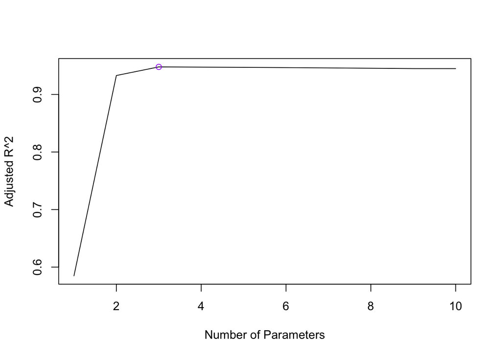

```r
#Adjusted R^2
plot(1:10, summary1$adjr2, xlab="Number of Parameters", ylab="Adjusted R^2", type = "l")
max_adjr2_1 <- max(summary1$adjr2)
points(c(1:10)[summary1$adjr2==max_adjr2_1], max_adjr2_1, pch=1, col="purple")
```

```r
#report the coefficients
lm6<-lm(y~I(x)+I(x^2)+I(x^3)+I(x^4)+I(x^6)+I(x^7)+I(x^8), data=data.frame(x=x,y=y) )
summary(lm6)
```

```
##
## Call:
## lm(formula = y ~ I(x) + I(x^2) + I(x^3) + I(x^4) + I(x^6) + I(x^7) +
##     I(x^8), data = data.frame(x = x, y = y))
##
## Residuals:
##     Min      1Q  Median      3Q     Max
## -1.9539 -0.5984 -0.1397  0.5722  2.1322
##
## Coefficients:
##              Estimate Std. Error t value Pr(>|t|)
## (Intercept)  3.086421   0.180910  17.061  < 2e-16 ***
## I(x)         2.284190   0.264448   8.638 1.68e-13 ***
## I(x^2)      -3.035969   0.801660  -3.787 0.000272 ***
## I(x^3)       0.059308   0.179183   0.331 0.741402
## I(x^4)      -0.252602   0.768054  -0.329 0.742990
## I(x^6)       0.094881   0.243681   0.389 0.697905
## I(x^7)       0.008660   0.006581   1.316 0.191465
## I(x^8)      -0.009436   0.024313  -0.388 0.698850
## ---
## Signif. codes:  0 '***' 0.001 '**' 0.01 '*' 0.05 '.' 0.1 ' ' 1
##
## Residual standard error: 0.9626 on 92 degrees of freedom
## Multiple R-squared:  0.9498, Adjusted R-squared:  0.946
## F-statistic: 248.7 on 7 and 92 DF,  p-value: < 2.2e-16
```

The answers are the same as those results in (c).

5. Now fit a LASSO model with `glmnet` function from `glmnet` package to the simulated data, again using $(X,X^2,\cdots,X^{10})$ as predictors. Use cross-validation to select the optimal value of $\lambda$. Create plots of the cross-validation error as a function of $\lambda$. Report the resulting coefficient estimates, and discuss the results obtained.

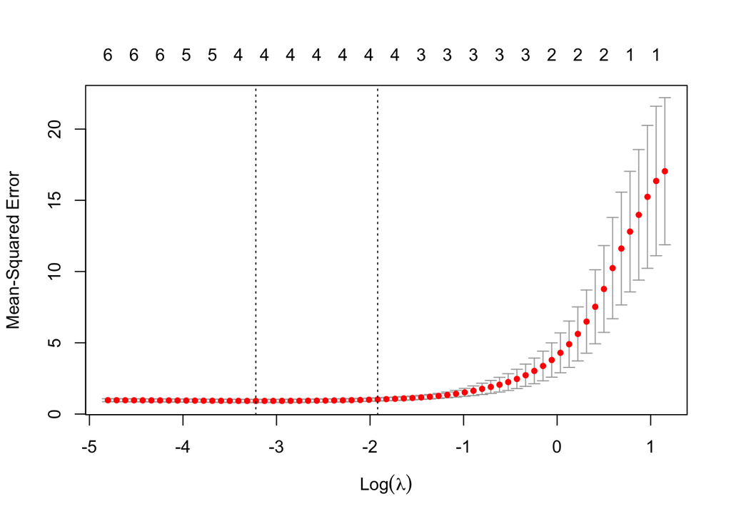

```r
library(glmnet)
x1=cbind(x,x^2,x^3,x^4,x^5,x^6,x^7,x^8,x^9,x^10)
y=y
# Cross-validation to select lambda
lasso.cv = cv.glmnet(x1,y, alpha=1)
lad<- lasso.cv$lambda.min
plot(lasso.cv)
```

```r
# coefficient estimate when refitting model with lamda.min
lamodel=glmnet(x1,y,alpha=1, lambda=lad)
summary(lamodel)
```

```
##           Length Class     Mode
## a0         1     -none-    numeric
## beta      10     dgCMatrix S4
## df         1     -none-    numeric
## dim        2     -none-    numeric
## lambda     1     -none-    numeric
## dev.ratio  1     -none-    numeric
## nulldev    1     -none-    numeric
## npasses    1     -none-    numeric
## jerr       1     -none-    numeric
## offset     1     -none-    logical
## call       5     -none-    call
## nobs       1     -none-    numeric
```

```r
coef(lamodel)
```

```
## 11 x 1 sparse Matrix of class "dgCMatrix"
##                       s0
## (Intercept)  3.040337084
## x            2.250503961
##             -3.105904642
##              .
##              .
##              0.040046945
##              .
##              0.002560369
##              .
##              .
##              .
```

6. Now generate a response vector $Y$ according to the model
   $$Y = \beta_0 + \beta_7 X^7 + \epsilon,$$
   where $\beta_7 = 7$, and perform best subset selection and the LASSO. Discuss the results obtained.

```r
y1 <- 3 + 7 * x^7 + epsilon
#best subsets
library(leaps)
sub_full <- regsubsets(y~x+I(x^2)+I(x^3)+I(x^4)+I(x^5)+I(x^6)+I(x^7)+I(x^8)
                    +I(x^9)+I(x^10),data=data.frame(x=x,y=y1),nvmax=10)
sub_summary <- summary(sub_full)
```

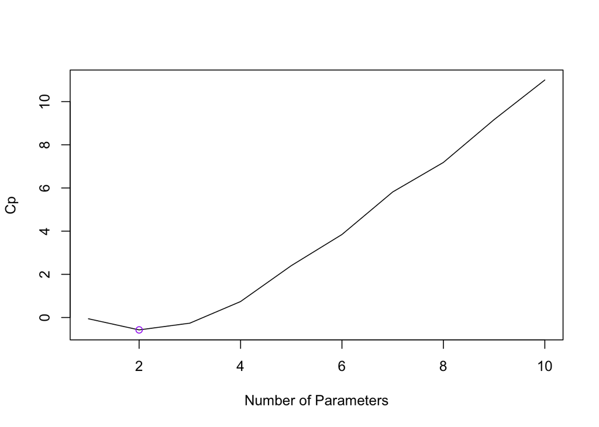

```r
#Cp
plot(1:10, sub_summary$cp, xlab="Number of Parameters", ylab="Cp", type = "l")
subset_min_cp <- min(sub_summary$cp)
points(c(1:10)[sub_summary$cp==subset_min_cp], subset_min_cp, pch=1, col="purple")
```

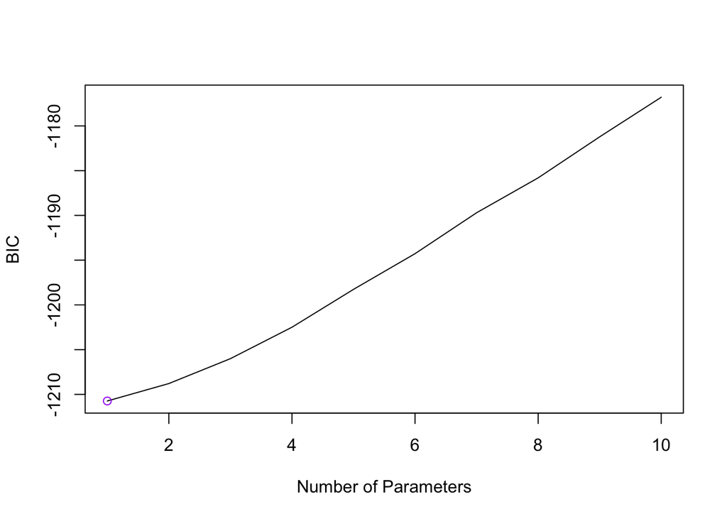

```r
#BIC
plot(1:10, sub_summary$bic, xlab="Number of Parameters", ylab="BIC", type = "l")
subset_min_bic <- min(sub_summary$bic)
points(c(1:10)[sub_summary$bic==subset_min_bic], subset_min_bic, pch=1, col="purple")
```

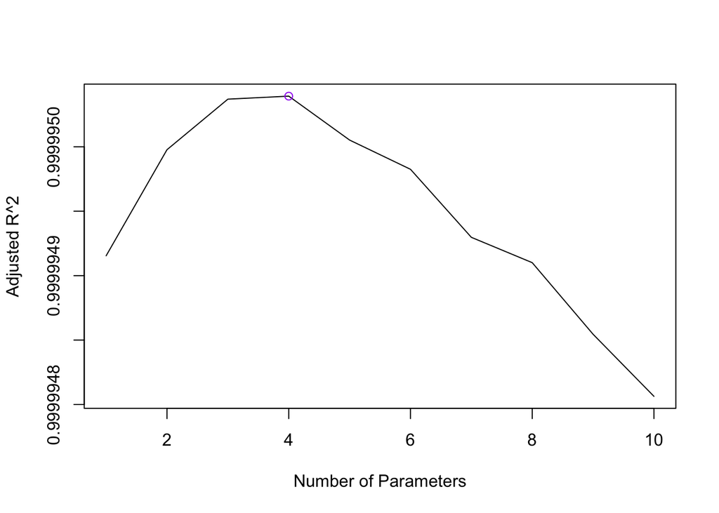

```r
#adjusted r^2
plot(1:10, sub_summary$adjr2, xlab="Number of Parameters", ylab="Adjusted R^2", type = "l")
subset_max_adjr2 <- max(sub_summary$adjr2)
points(c(1:10)[sub_summary$adjr2==subset_max_adjr2], subset_max_adjr2, pch=1, col="purple")
```

If we perform best subset selection, the best model obtained according to $C_p$ has 2 parameters, which are $X^2$ and $X^7$; the best model obtained according to $BIC$ has only 1 parameter, which is $X^7$; the best model obtained according to adjusted $R^2$ has 4 parameters, which are $X$, $X^2$, $X^3$ and $X^7$.

2. (Prediction, [ISL] 6.9, *20 pt*) In this exercise, we will predict the number of applications received (`Apps`) using the other variables in the `College` data set from `ISLR` package.
   1. Randomly split the data set into equal sized training set and test set (1:1).
   2. Fit a linear model using least squares on the training set, and report the test error obtained.
   3. Fit a ridge regression model on the training set, with $\lambda$ chosen by 5-fold cross-validation. Report the test error obtained.
   4. Fit a LASSO model on the training set, with $\lambda$ chosen by 5-fold cross-validation. Report the test error obtained, along with the number of non-zero coefficient estimates.
   5. Comment on the results obtained. How accurately can we predict the number of college applications received? Is there much difference among the test errors resulting from these three approaches?